# Implied Volatility

```r
# call_option function

call_option <- function(p0, K, T, r, sigma, N) {

returnList    <- list()
optionPayoffs <- vector()
dt            <- 1/260              # no of periods per year
Periods       <- T/dt
rInt          <- r*dt
sigmaInt      <- sigma*sqrt(dt)

for(i in 1:N){
  returns=rnorm(Periods,rInt,sigmaInt)
  prices=p0*cumprod(returns+1)
  optionPayoffs[i]=max(prices[Periods]-K,0)
}

optPrice=mean(optionPayoffs)
#returnList$optionPayoffs <- optionPayoffs
returnList$optPrice <- optPrice
returnList

}

# Calibration parameters from https://finance.yahoo.com/quote/GILD/options?p=GILD&date=1495152000
# Expires May 19, 2017

p0    <-  74.04               # current price
K     <-  75.0                # strike price
T     <-  124/260             # no of years to run simulation
sigma <-  .2578               # st deviation of stock # act .2249
N     <-  10000               # number of iterations
r     <-  0.00                # estimated return of stock

call_option(p0, K, T, r, sigma, N)
```

```
## $optPrice
## [1] 4.921731
```

Here, we use a while loop to find the implied volatility $\sigma_{imp}$ with precision. We ran a while loop for $.24 \leq \sigma_{imp} \leq .26$ given that the implied volatility on Yahoo was aroung .25. The increment was $.0001$. The loop is commented out because it is not necessary to run more than once for our purposes here.

```
## 0.2591 is implied volatility
```

Here, we run a loop with much less precision in order to show how price changes with various values for $\sigma$.

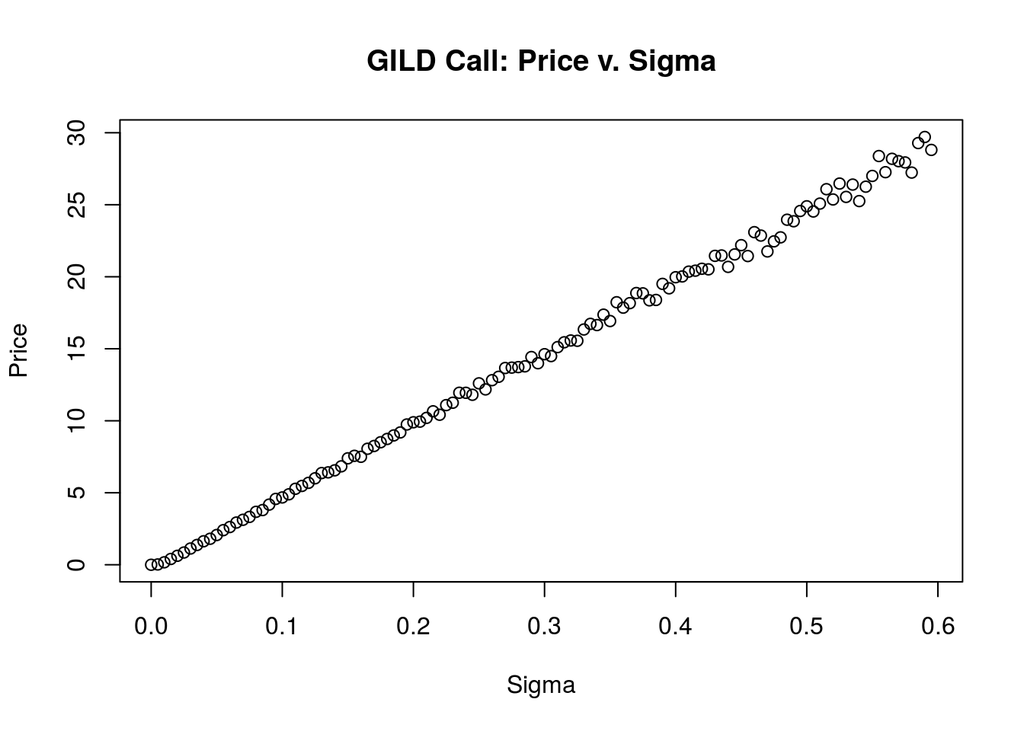

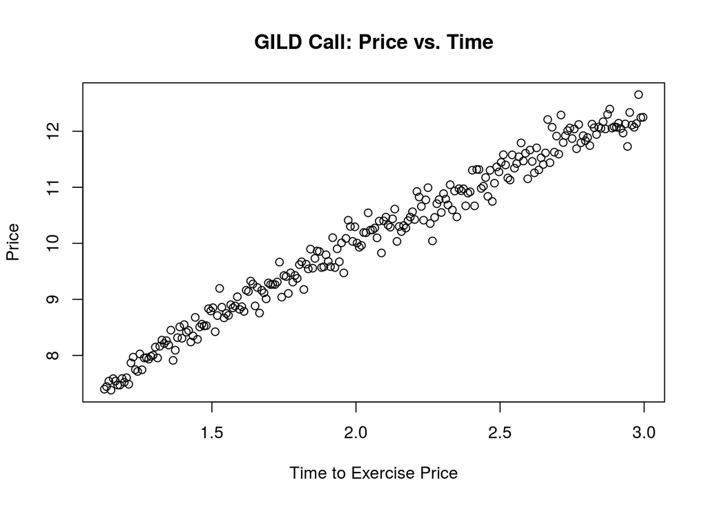

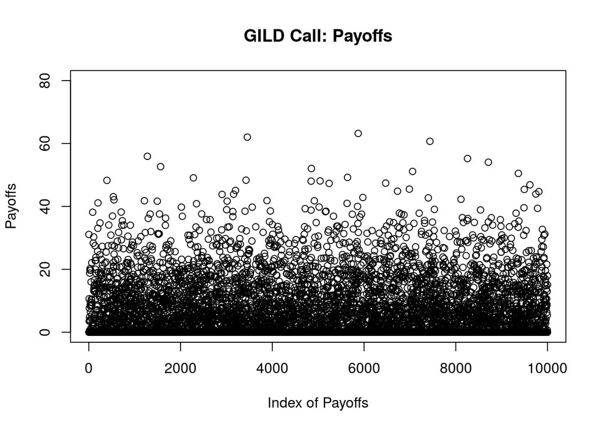

```r
# Pricing an asian option
# ***********************
p0    <-  74.04              # current price
K     <-  75.0               # strike price
T     <-  124/260            # no of years to run simulation
sigma <-  .2591              # st deviation of stock # act .2249
N     <-  10000              # number of iterations
r     <-  0.00               # estimated return of stock

# SOURCE
# https://finance.yahoo.com/quote/GILD/options?p=GILD&date=1495152000
# Expires May 19, 2017

asian_option <- function(p0, K, T, r, sigma, N) {

returnList    <- list()
optionPayoffs <- vector()
dt            <- 1/260              # no of periods per year
Periods       <- T/dt
rInt          <- r*dt
sigmaInt      <- sigma*sqrt(dt)

for(i in 1:N){
  returns=rnorm(Periods,rInt,sigmaInt)
  prices=p0*cumprod(returns+1)
  avgPrice <- mean(prices)         #### This is the significant difference in code
                                   #### vs. the regular call_option function.
  optionPayoffs[i]=max(avgPrice-K,0)
}

optPrice=mean(optionPayoffs)
returnList$optionPayoffs <- optionPayoffs
returnList$optPrice <- optPrice
returnList

}


plot(call_option_payoffs(p0, K, T, r, sigma, N)$optionPayoffs, xlab = "Index of Payoffs", ylab = "Payoffs", main = "GILD Call: Payoffs", ylim = c(0, 80))
```

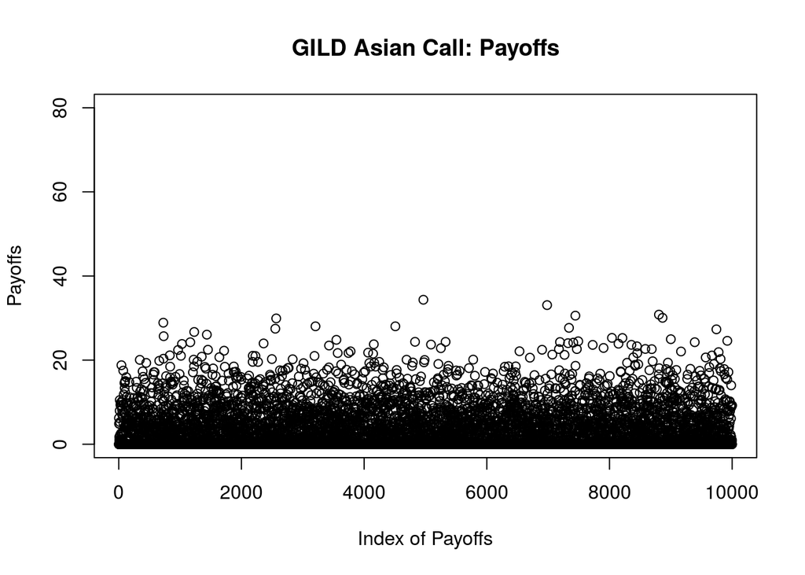

```r
plot(asian_option(p0, K, T, r, sigma, N)$optionPayoffs, xlab = "Index of Payoffs", ylab = "Payoffs", main = "GILD Asian Call: Payoffs", ylim = c(0, 80))
```

```r
asian_option(p0, K, T, r, sigma, N)$optPrice
```

```
## [1] 2.620548
```

We chose Gilead Sciences, a pharmaceutical company for our option. The stock is currently priced at 74.04 and the closest option at this price was 75. According to Yahoo Finance, the currently implied volatility is 25.78%. Our implied volatility was calculated to be 25.91%.

We chose to price an Asian option. The profit from an Asian option is calculated as the average stock price over the period minus a given stike price. If this criteria is not met, the option is not exercised. The way the Asian option was priced was by manipulating the original function, call_option, by taking the average of the prices over the period and finding the expected payoff over the period. The price of the option found on Yahoo Finance and the one calculated with call_option were both very close to 4.90. However, for our Asian option, the price a little over half this price at 2.61 approximately. We posit that this may be due to the fact that options increase in price with volatility. However, if we take the average returns over a period of time in order to calculate the payoff, the benefits of volatility are diminished. This can be visualised in the plots above. The payoffs for the Asian option remain below 40 whereas for a regular call the possible payoffs are nearly double this value.